# Bellabeat Case Study

### 5.5 Smart Device Usage Timeline/day

As we move further ahead with our analysis, next we will find the total time period for which a user wears the smart device throughout the day and for the same we are merging daily_use and daily_activity data frames.

```r
daily_use_merged <- merge(daily_activity, daily_use, by=c ("Id"))
head(daily_use_merged)
```

```
##           Id       date TotalSteps TotalDistance TrackerDistance
## 1 1503960366 2016-05-07      11992          7.71            7.71
## 2 1503960366 2016-05-06      12159          8.03            8.03
## 3 1503960366 2016-05-01      10602          6.81            6.81
## 4 1503960366 2016-04-30      14673          9.25            9.25
## 5 1503960366 2016-04-12      13162          8.50            8.50
## 6 1503960366 2016-04-13      10735          6.97            6.97
##   LoggedActivitiesDistance VeryActiveDistance ModeratelyActiveDistance
## 1                        0               2.46                     2.12
## 2                        0               1.97                     0.25
## 3                        0               2.29                     1.60
## 4                        0               3.56                     1.42
## 5                        0               1.88                     0.55
## 6                        0               1.57                     0.69
##   LightActiveDistance SedentaryActiveDistance VeryActiveMinutes
```

[output cut: 20 more lines]

Let’s construct a new data frame that divides the total daily minutes consumers spent wearing the gadget into three categories:

1. All Day
2. More than half day
3. Less than half day

```r
minutes_worn <- daily_use_merged %>%
  mutate(total_minutes_worn = VeryActiveMinutes +
           FairlyActiveMinutes +
           LightlyActiveMinutes +
           SedentaryMinutes)%>%
  mutate (percent_minutes_worn = (total_minutes_worn/1440)*100) %>%
  mutate (worn = case_when(
    percent_minutes_worn == 100 ~ "All day",
    percent_minutes_worn < 100 & percent_minutes_worn >= 50~ "More than half day",
    percent_minutes_worn < 50 & percent_minutes_worn > 0 ~ "Less than half day"
  ))

head(minutes_worn)
```

```
##           Id       date TotalSteps TotalDistance TrackerDistance
## 1 1503960366 2016-05-07      11992          7.71            7.71
## 2 1503960366 2016-05-06      12159          8.03            8.03
## 3 1503960366 2016-05-01      10602          6.81            6.81
## 4 1503960366 2016-04-30      14673          9.25            9.25
## 5 1503960366 2016-04-12      13162          8.50            8.50
## 6 1503960366 2016-04-13      10735          6.97            6.97
##   LoggedActivitiesDistance VeryActiveDistance ModeratelyActiveDistance
## 1                        0               2.46                     2.12
## 2                        0               1.97                     0.25
## 3                        0               2.29                     1.60
## 4                        0               3.56                     1.42
## 5                        0               1.88                     0.55
## 6                        0               1.57                     0.69
##   LightActiveDistance SedentaryActiveDistance VeryActiveMinutes
```

[output cut: 20 more lines]

Going ahead we will be creating data frame for better visualization

This data frame will show the total number of users and calculate the total percentage time for which the device was worn.

```r
minutes_worn_percent <- minutes_worn%>%
  group_by(worn) %>%
  summarise(total = n()) %>%
  mutate(totals = sum(total)) %>%
  group_by(worn) %>%
  summarise(total_percent = total / totals) %>%
  mutate(labels = scales::percent(total_percent))

minutes_worn_highuse <- minutes_worn%>%
  filter (usage == "high use")%>%
  group_by(worn) %>%
  summarise(total = n()) %>%
  mutate(totals = sum(total)) %>%
  group_by(worn) %>%
  summarise(total_percent = total / totals) %>%
  mutate(labels = scales::percent(total_percent))
minutes_worn_moduse <- minutes_worn%>%
  filter(usage == "moderate use") %>%
  group_by(worn) %>%
  summarise(total = n()) %>%
  mutate(totals = sum(total)) %>%
  group_by(worn) %>%
  summarise(total_percent = total / totals) %>%
  mutate(labels = scales::percent(total_percent))
minutes_worn_lowuse <- minutes_worn%>%
  filter (usage == "low use") %>%
  group_by(worn) %>%
  summarise(total = n()) %>%
  mutate(totals = sum(total)) %>%
  group_by(worn) %>%
  summarise(total_percent = total / totals) %>%
  mutate(labels = scales::percent(total_percent))
minutes_worn_highuse$worn <- factor(minutes_worn_highuse$worn, levels = c("All day", "More than half day", "Less than half day"))
minutes_worn_percent$worn <- factor(minutes_worn_percent$worn, levels = c("All day", "More than half day", "Less than half day"))
minutes_worn_moduse$worn <- factor(minutes_worn_moduse$worn, levels = c("All day", "More than half day", "Less than half day"))
minutes_worn_lowuse$worn <- factor(minutes_worn_lowuse$worn, levels = c("All day", "More than half day", "Less than half day"))


head(minutes_worn_percent)
```

```
## # A tibble: 3 × 3
##   worn               total_percent labels
##   <fct>                      <dbl> <chr>
## 1 All day                   0.365  36%
## 2 Less than half day        0.0351 4%
## 3 More than half day        0.600  60%
```

```r
head(minutes_worn_highuse)
```

```
## # A tibble: 0 × 3
## # Groups:   worn [0]
## # … with 3 variables: worn <fct>, total_percent <dbl>, labels <chr>
```

```r
head(minutes_worn_moduse)
```

```
## # A tibble: 0 × 3
## # Groups:   worn [0]
## # … with 3 variables: worn <fct>, total_percent <dbl>, labels <chr>
```

```r
head(minutes_worn_lowuse)
```

```
## # A tibble: 0 × 3
## # Groups:   worn [0]
## # … with 3 variables: worn <fct>, total_percent <dbl>, labels <chr>
```

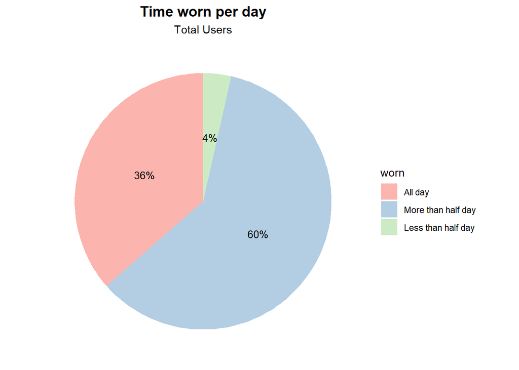

```r
ggplot(minutes_worn_percent, aes(x="",y=total_percent, fill=worn)) +
  geom_bar(stat = "identity", width = 1)+
  coord_polar("y", start=0)+
  theme_minimal()+
  theme(axis.title.x= element_blank(),
        axis.title.y = element_blank(),
        panel.border = element_blank(),
        panel.grid = element_blank(),
        axis.ticks = element_blank(),
        axis.text.x = element_blank(),
        plot.title = element_text(hjust = 0.5, size=14, face = "bold"),
        plot.subtitle = element_text(hjust = 0.5)) +
  scale_fill_brewer(palette='Pastel1')+
  geom_text(aes(label = labels),
            position = position_stack(vjust = 0.5), size = 3.5)+
  labs(title="Time worn per day", subtitle = "Total Users")
```

As per the above chart we can see that 36% of the total of users wear the device all day long, 60% more than half day long and just 4% for less than half a day.

## 6. ACT Phase (Conclusion)

Bellabeat’s goal is to empower women by giving them the knowledge to learn about themselves.

Based on our findings, I would advise using your own monitoring data for more analysis in order for us to respond to our business task and assist Bellabeat with their purpose. Since we lacked information on the users’ demographics, the datasets we used have a limited sample and are potentially biased. Knowing that young and adult women are our primary target demographic, I would encourage you to keep looking for trends so you can develop a marketing strategy centred on them.

Having said that, following our investigation, we identified a number of tendencies that could benefit our online campaign and enhance the Bellabeat app:

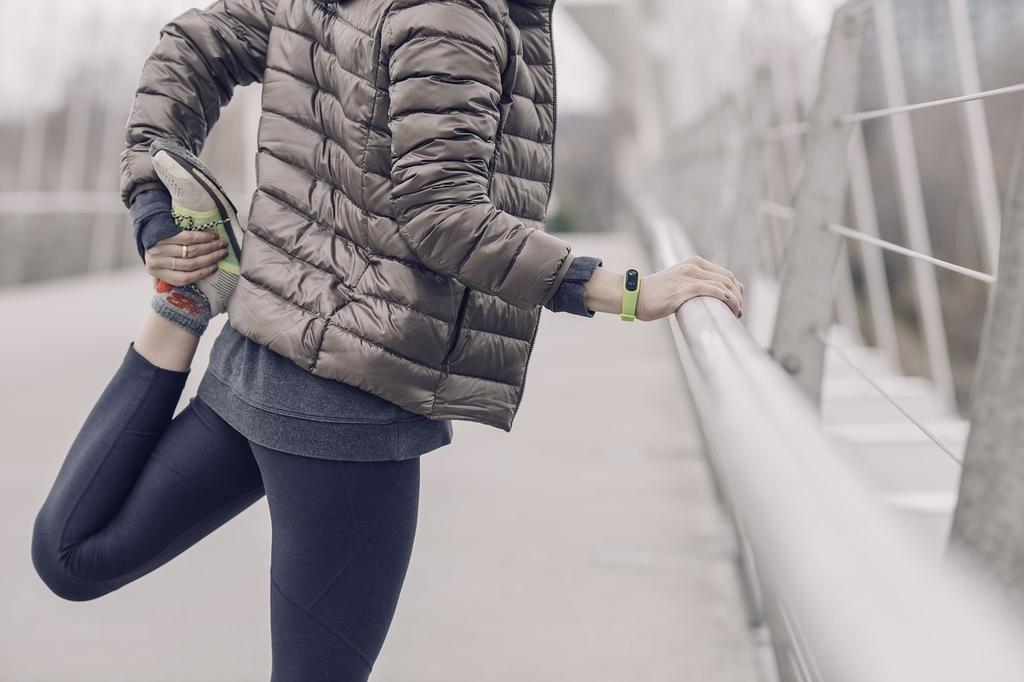